# Lofexidine and Opioid Withdrawal: Beyond the Impact of Blood Pressure

Zakk Heile, Kanthi Makineedi, Matthew O’Donnell, Yash Singam, Lisa Zhang and Raphael Morsomme

## Reexamining Previous Study

- Lofexidine: mitigates opioid withdrawal
- Reduces withdrawal severity with fewer side effects compared to similar treatments
- Current Knowledge: Lofexidine found to lower blood pressure (BP)

**Our Study**

- Goal: Does Lofexidine impact withdrawal beyond blood pressure?
- Impact: There may be better (cheaper or more targeted) treatments for withdrawal

## Data

- Predominantly male sample (87%)
- Small sample size (68), limits generalizability
- Participants have a history of opioid dependence

## Linear Regression Model

$$\begin{equation}
\label{eq:model}
y_i = \alpha + \beta z_i + \gamma^T x_i + \epsilon_i, \qquad i=1,2,\dots,44,
\end{equation}$$

#### Model Parameters

- Intercept: $\alpha$
- Treatment effect: $\beta$
- Regression coefficients: $\gamma$

#### Variables

- MHOWS: $y_i$
- Treatment: $z_i\in\{0,1\}$
- Covariates: $x_i\in R^2$
- Error: $\epsilon_i \overset{\text{i.i.d.}}{\sim} N(0, \sigma^2)$

## Cohort Mean for Potential Covariates

| Covariate | Lofexidine | Placebo | Total |
| --- | --- | --- | --- |
| **Age*** | 42.0 | 40.5 | 41.3 |
| % Male | 88.6% | 84.8% | 86.8% |
| Opioid Use | 29.4 | 29.2 | 29.3 |
| **Tobacco Use*** | 19.43 | 19.48 | 19.46 |
| Baseline BP | 123.0 | 123.2 | 123.1 |

***Chosen for final model**

## Response Variable

Composite MHOWS score excluding blood pressure

- Day 5
- Discrete MHOWS variables
  - anorexia score imputation
  - conversion to factors
- Continuous MHOWS variables
  - imputation of missing values
  - calculate comparisons to baseline (day 1 and/or 2)

## Results

- Treatment Visualization
- Sensitivity Analysis

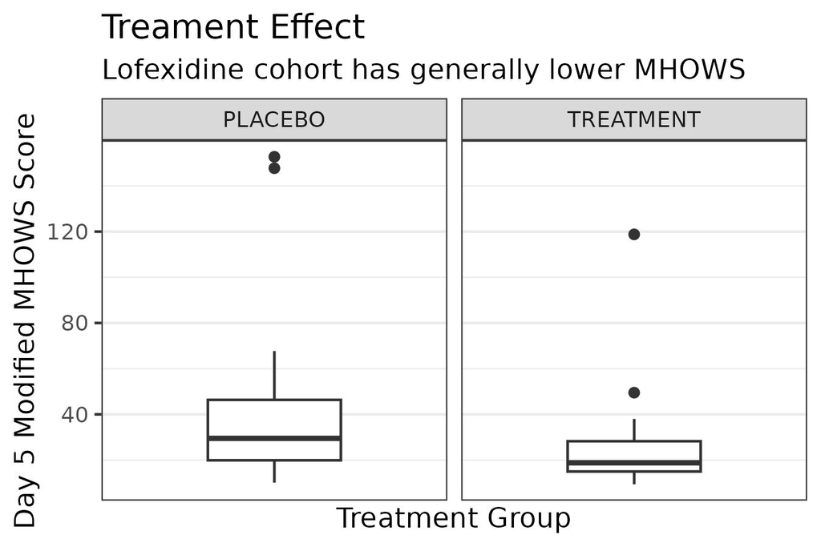

| Predictor | M.L.E. | p-value |
| --- | --- | --- |
| Intercept | 5.505 / 5.343 | 0.829 / 0.834 |
| Age | 0.736 / 0.740 | 0.218 / 0.215 |
| Lofexidine Treatment | -16.800 / -16.912 | **0.072 / 0.070** |
| Tobacco Use | 0.359 / 0.358 | 0.349 / 0.350 |

## Discussion

- Does Lofexidine impact withdrawal beyond blood pressure?
  - The effect of Lofexidine is not statistically significant
- Future Work:
  - Larger sample size
  - Better patient retention
  - Modelling dropout

# Thank you! Questions?

Introduction to Undergraduate Research in Statistics Workshop (2024)